# Whole Foods

Chunzi Wang

March 17, 2018

```r
library(dplyr)
library(ggplot2)
library(treemap)
```

```r
transaction <- read.csv("Whole_Foods_Transaction_Data.csv")
```

```r
head(transaction)
```

```
##   transaction_id product_id reordered
## 1             10      26842         0
## 2             10       1529         0
## 3             10      31717         0
## 4             10      21137         1
## 5             10      24852         1
## 6             10      47766         1
##                                 product_name aisle_id department_id
## 1                Boneless Beef Sirloin Steak      122            12
## 2 Parsley, Italian (Flat), New England Grown       16             4
## 3                           Organic Cilantro       16             4
## 4                       Organic Strawberries       24             4
## 5                                     Banana       24             4
## 6                            Organic Avocado       24             4
##     department        aisle
## 1 meat seafood meat counter
## 2      produce  fresh herbs
## 3      produce  fresh herbs
## 4      produce fresh fruits
## 5      produce fresh fruits
## 6      produce fresh fruits
```

```r
str(transaction)
```

```
## 'data.frame':    250000 obs. of  8 variables:
##  $ transaction_id: int  10 10 10 10 10 10 10 10 10 10 ...
##  $ product_id    : int  26842 1529 31717 21137 24852 47766 49235 27156 14992 25720 ...
##  $ reordered     : int  0 0 0 1 1 1 1 0 0 0 ...
##  $ product_name  : Factor w/ 23323 levels "\\\"Darn Good\\\" Chili Mix",..: 2296 16174 13443 15049 1606 13066 14002 13164 8535 15085 ...
##  $ aisle_id      : int  122 16 16 24 24 24 53 59 83 83 ...
##  $ department_id : Factor w/ 23 levels "1","10","11",..: 4 16 16 16 16 16 8 7 16 16 ...
##  $ department    : Factor w/ 23 levels "alcohol","babies",..: 14 22 22 22 22 22 8 7 22 22 ...
##  $ aisle         : Factor w/ 135 levels "","air fresheners candles",..: 84 53 53 52 52 52 35 23 55 55 ...
```

```r
summary(transaction)
```

```
##  transaction_id      product_id      reordered
##  Min.   :     10   Min.   :    1   Min.   :0.0000
##  1st Qu.:1003917   1st Qu.:13512   1st Qu.:0.0000
##  Median :1010511   Median :25256   Median :1.0000
##  Mean   : 919816   Mean   :25573   Mean   :0.5878
##  3rd Qu.:1017217   3rd Qu.:38015   3rd Qu.:1.0000
##  Max.   :1023856   Max.   :49683   Max.   :1.0000
##
##                  product_name       aisle_id      department_id
##  Banana                :  3660   Min.   :  1.00   4      :72677
##  Bag of Organic Bananas:  2870   1st Qu.: 31.00   16     :41497
##  Organic Strawberries  :  2003   Median : 83.00   19     :22321
##  Organic Baby Spinach  :  1849   Mean   : 71.29   7      :20987
##  Organic Hass Avocado  :  1646   3rd Qu.:107.00   1      :17489
##  Organic Avocado       :  1322   Max.   :134.00   13     :14327
##  (Other)               :236650                    (Other):60702
##       department                           aisle
##  produce   :72677   fresh fruits              : 27864
##  dairy eggs:41497   fresh vegetables          : 26172
##  snacks    :22321   packaged vegetables fruits: 13599
##  beverages :20987   yogurt                    : 11073
##  frozen    :17489   packaged cheese           :  7392
##  pantry    :14327   milk                      :  6907
##  (Other)   :60702   (Other)                   :156993
```

There’re 24896 unique transactions.

```r
length(unique(transaction$transaction_id))
```

```
## [1] 24896
```

```r
transaction %>%
  group_by(transaction_id) %>%
  count()
```

```
## # A tibble: 24,896 x 2
## # Groups:   transaction_id [24,896]
##    transaction_id     n
##             <int> <int>
##  1             10    15
##  2            100     2
##  3            101    12
##  4            102    10
##  5           1000     7
##  6           1002    33
##  7           1003    11
##  8           1004     7
##  9           1005    13
## 10           1006    11
## # ... with 24,886 more rows
```

```r
#same
#transaction %>%
  #count(transaction_id)
```

Find bestsellers:

```r
bestsellers <- transaction %>%
  group_by(product_name) %>%
  summarize(count=n()) %>%
  arrange(desc(count))
bestsellers
```

```
## # A tibble: 23,323 x 2
##    product_name           count
##    <fct>                  <int>
##  1 Banana                  3660
##  2 Bag of Organic Bananas  2870
##  3 Organic Strawberries    2003
##  4 Organic Baby Spinach    1849
##  5 Organic Hass Avocado    1646
##  6 Organic Avocado         1322
##  7 Large Lemon             1189
##  8 Limes                   1136
##  9 Organic Whole Milk      1048
## 10 Strawberries            1048
## # ... with 23,313 more rows
```

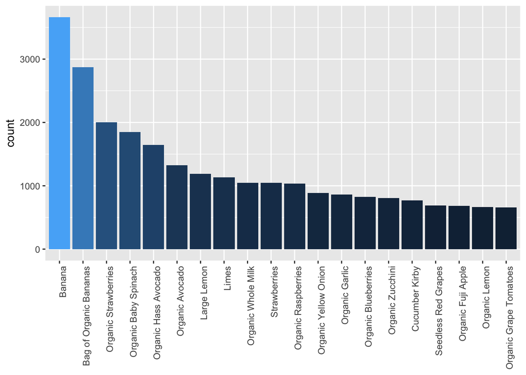

```r
bestsellers %>%
  top_n(20) %>%
  ggplot(aes(x=reorder(product_name,-count),y=count,fill=count))+
  geom_col(show.legend = FALSE)+
  theme(axis.text.x=element_text(angle=90,hjust=1),axis.title.x=element_blank())
```

Find pattern in reordered items:

```r
transaction %>%
  group_by(reordered) %>%
  summarize(count=n())
```

```
## # A tibble: 2 x 2
##   reordered  count
##       <int>  <int>
## 1         0 103054
## 2         1 146946
```

```r
reordered <- transaction %>%
  filter(reordered==1) %>%
  group_by(product_name) %>%
  summarize(count=n()) %>%
  arrange(desc(count))
reordered
```

```
## # A tibble: 16,244 x 2
##    product_name           count
##    <fct>                  <int>
##  1 Banana                  3091
##  2 Bag of Organic Bananas  2407
##  3 Organic Strawberries    1504
##  4 Organic Baby Spinach    1425
##  5 Organic Hass Avocado    1283
##  6 Organic Avocado          976
##  7 Organic Whole Milk       846
##  8 Large Lemon              810
##  9 Organic Raspberries      773
## 10 Limes                    744
## # ... with 16,234 more rows
```

Large overlap of reordered items and bestsellers. Check the propability of each item being reordered.

Set the count threshold to 100 since we’re more interested in products that are more popular with the general public. This time, milk especially, and water, eggs, soda, coconut water, yogurt are the highest propability of reordered. Consider it beverage category. People who drink milk tend to drink it every day and refill it constantly.

```r
proportion_reordered <- transaction %>%
  group_by(product_name) %>%
  summarise(proportion_reordered = mean(reordered), count=n()) %>%
  filter(count>100) %>%
  arrange(desc(proportion_reordered))
proportion_reordered
```

```
## # A tibble: 344 x 3
##    product_name                            proportion_reordered count
##    <fct>                                                  <dbl> <int>
##  1 Organic Reduced Fat Milk                               0.872   298
##  2 Italian Sparkling Mineral Water                        0.862   240
##  3 Milk, Organic, Vitamin D                               0.860   129
##  4 Organic Lowfat 1% Milk                                 0.851   121
##  5 Banana                                                 0.845  3660
##  6 Organic Unsweetened Vanilla Almond Milk                0.843   108
##  7 Bag of Organic Bananas                                 0.839  2870
##  8 Spring Water                                           0.838   426
##  9 Organic Fat Free Milk                                  0.827   214
## 10 Organic Large Grade AA Brown Eggs                      0.827   185
## # ... with 334 more rows
```

There’re more than 4000 kinds of products that’re 100% reordered but the total times they are bought are comparatively small. They serve niche market but the customers who bought them are extremely loyal.

```r
transaction %>%
  group_by(product_name) %>%
  summarise(proportion_reordered = mean(reordered), count=n()) %>%
  filter(proportion_reordered==1) %>%
  arrange(desc(count))
```

```
## # A tibble: 4,658 x 3
##    product_name                           proportion_reordered count
##    <fct>                                                 <dbl> <int>
##  1 Original Cherry Orchard Yogurt                           1.    13
##  2 Unsweetened Pure & Smooth  Green Tea                     1.    12
##  3 Little Sumpin' Sumpin' Ale                               1.    11
##  4 Aged White Cheddar Puffs Cheese Snacks                   1.    10
##  5 Artesano Style Bread                                     1.     9
##  6 Organic 14 Grain Bread                                   1.     9
##  7 Organic Elmo Noodlemania Soup                            1.     9
##  8 Raspberry Lime Sparkling Seltzer Water                   1.     9
##  9 Temptations Cat Treats - Creamy Dairy                    1.     9
## 10 Unsweetened Elegant Jasmine Green Tea                    1.     9
## # ... with 4,648 more rows
```

Association between number of orders and probability of reordering, although some small countes of orders have high reordered rate, in general, there’s a upward trend that shows a high number of orders are naturally more likely ro be reordered.

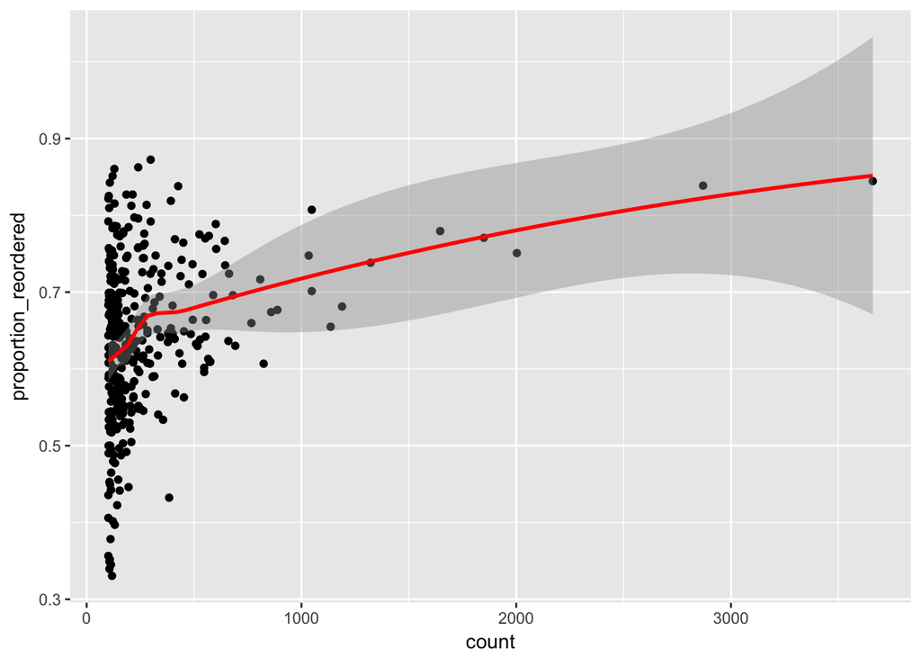

```r
proportion_reordered %>%
  ggplot(aes(x=count,y=proportion_reordered))+
  geom_point()+
  geom_smooth(color="red")
```

Visualizing product porfolio

```r
portfolio <- transaction %>%
  group_by(department,aisle) %>%
  summarise(count=n()) %>%
  ungroup() %>%
  group_by(department) %>%
  mutate(dep_sumcount=sum(count)) %>%
  ungroup() %>%
  mutate(onesize=1)
portfolio
```

```
## # A tibble: 136 x 5
##    department aisle                      count dep_sumcount onesize
##    <fct>      <fct>                      <int>        <int>   <dbl>
##  1 alcohol    beers coolers                393         1125      1.
##  2 alcohol    red wines                    203         1125      1.
##  3 alcohol    specialty wines champagnes    86         1125      1.
##  4 alcohol    spirits                      230         1125      1.
##  5 alcohol    white wines                  213         1125      1.
##  6 babies     baby accessories              48         3424      1.
##  7 babies     baby bath body care           68         3424      1.
##  8 babies     baby food formula           3086         3424      1.
##  9 babies     diapers wipes                222         3424      1.
## 10 bakery     bakery desserts              281         8972      1.
## # ... with 126 more rows
```

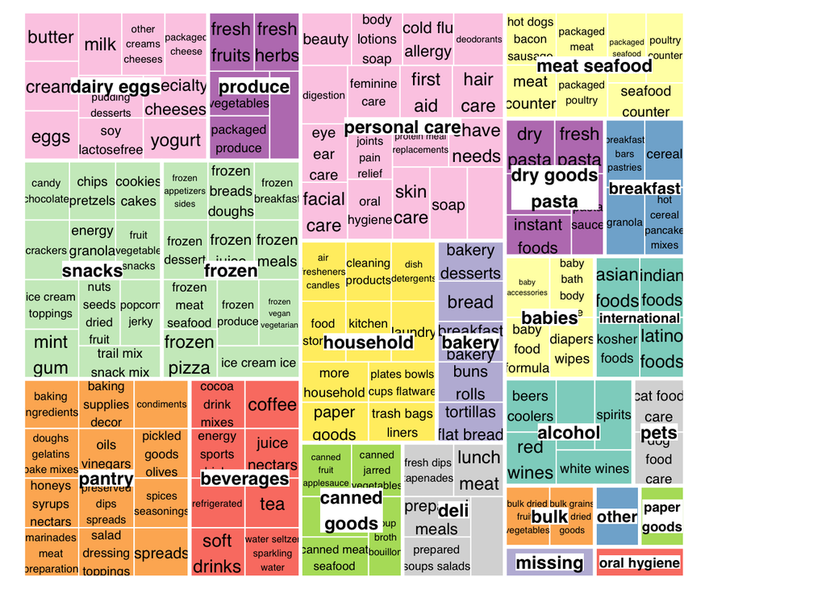

```r
treemap(portfolio,index=c("department","aisle"),vSize="onesize",vColor="department",palette="Set3",title="",sortID="-dep_sumcount",border.col="#FFFFFF",type="categorical",fontsize.legend=0,bg.labels="#FFFFFF")
```

How oftem are products from each department/aisle sold?

It’s clear that produce and diary eggs are the top 2 departments of all the transactions.

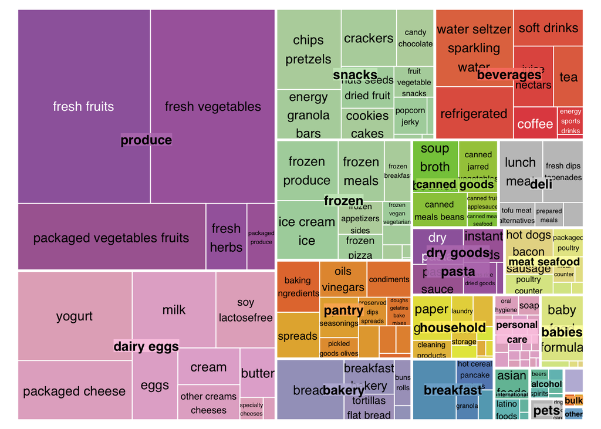

```r
treemap(portfolio,index=c("department","aisle"),vSize="count",title="",palette="Set3",border.col="#FFFFFF")
```

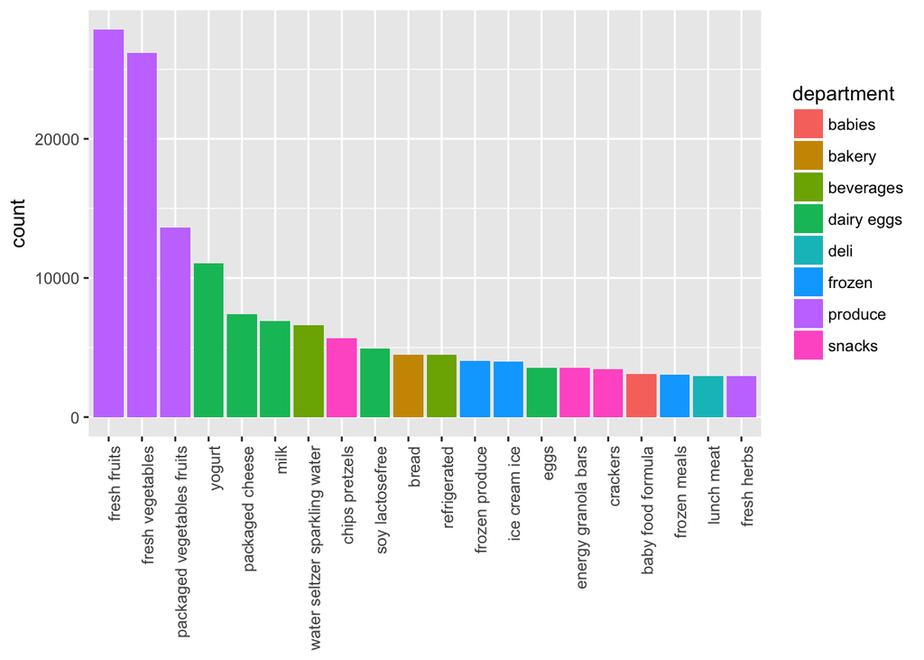

```r
portfolio %>%
  arrange(desc(count)) %>%
  top_n(20,count) %>%
  ggplot(aes(x=reorder(aisle,-count),y=count,fill=department))+
  geom_col()+
  theme(axis.text.x=element_text(angle=90,hjust=1),axis.title.x=element_blank())
```

Association Rules

```r
library(arules)
library(arulesViz)
```

```r
baskets <- transaction %>%
  group_by(transaction_id) %>%
  summarise(basket=as.vector(list(product_name)))
```

```r
class(baskets$basket)
```

```
## [1] "list"
```

```r
length(baskets$basket)
```

```
## [1] 24896
```

```r
baskets$basket[[1]]
```

```
##  [1] Boneless Beef Sirloin Steak
##  [2] Parsley, Italian (Flat), New England Grown
##  [3] Organic Cilantro
##  [4] Organic Strawberries
##  [5] Banana
##  [6] Organic Avocado
##  [7] Organic Half & Half
##  [8] Organic Black Beans
##  [9] Green Beans
## [10] Organic Sunchoke
## [11] Organic Butterhead (Boston, Butter, Bibb) Lettuce
## [12] Yellow Onions
## [13] Baby Portabella Mushrooms
## [14] Stage 2 Green Bean Pear Greek Yogurt Baby Food
## [15] Spinach Peas & Pear Stage 2 Baby Food
## 23323 Levels: \\"Darn Good\\" Chili Mix ...
```

```r
transactions <- as(baskets$basket,"transactions")
```

Look at frequent items:

```r
item_frequencies <- itemFrequency(transactions,type="a")
support <- 0.02
freq_items <- sort(item_frequencies,decreasing = F)
freq_items <- freq_items[freq_items>support*length(transactions)]
length(freq_items)
```

```
## [1] 39
```

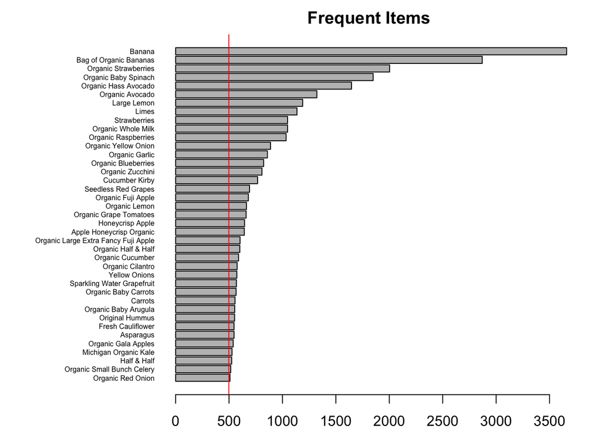

```r
par(mar=c(2,10,2,2)); options(scipen=5)
barplot(freq_items,horiz = T, las=1, main = "Frequent Items",cex.names = 0.5)
abline(v=support*length(transactions),col="red")
```

Frequent itemsets:

```r
support <- 0.008
itemsets <- apriori(transactions, parameter=list(target="frequent itemsets",supp=support,minlen=2),control=list(verbose=FALSE))
```

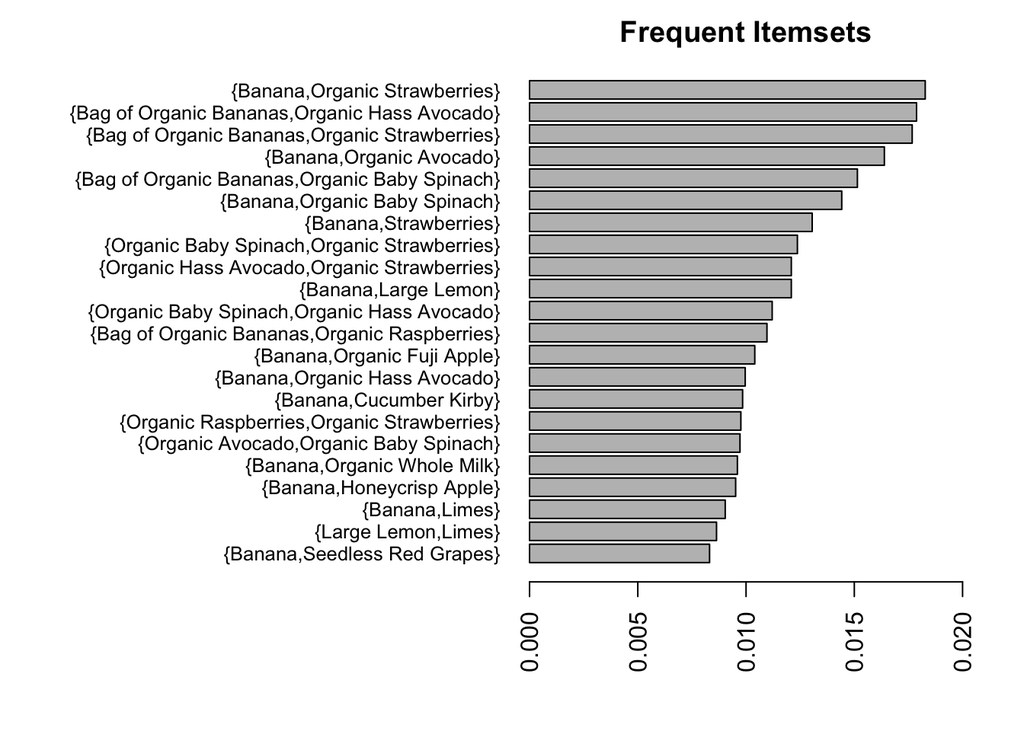

```r
par(mar=c(5,18,2,2)+0.1)
sets_order_supp <- DATAFRAME(sort(itemsets,by="support",decreasing = F))
barplot(sets_order_supp$support,names.arg = sets_order_supp$items,xlim=c(0,0.02),horiz=T,las=2,cex.names = 0.8,main="Frequent Itemsets")
```

Use a low support threshold and a high confidence to generate strong rules even for items that are less frequent.

```r
rules1 <- apriori(transactions,parameter=list(support=0.0001,conf=0.6,maxlen=3),control=list(verbose=FALSE))
summary(rules1)
```

```
## set of 19875 rules
##
## rule length distribution (lhs + rhs):sizes
##     2     3
##   602 19273
##
##    Min. 1st Qu.  Median    Mean 3rd Qu.    Max.
##    2.00    3.00    3.00    2.97    3.00    3.00
##
## summary of quality measures:
##     support            confidence          lift              count
##  Min.   :0.0001205   Min.   :0.6000   Min.   :   4.081   Min.   : 3.000
##  1st Qu.:0.0001205   1st Qu.:0.6000   1st Qu.:   6.802   1st Qu.: 3.000
##  Median :0.0001205   Median :0.7500   Median :  14.124   Median : 3.000
##  Mean   :0.0001365   Mean   :0.7625   Mean   : 138.629   Mean   : 3.397
##  3rd Qu.:0.0001205   3rd Qu.:1.0000   3rd Qu.:  47.832   3rd Qu.: 3.000
##  Max.   :0.0016067   Max.   :1.0000   Max.   :8298.667   Max.   :40.000
##
## mining info:
##          data ntransactions support confidence
##  transactions         24896  0.0001        0.6
```

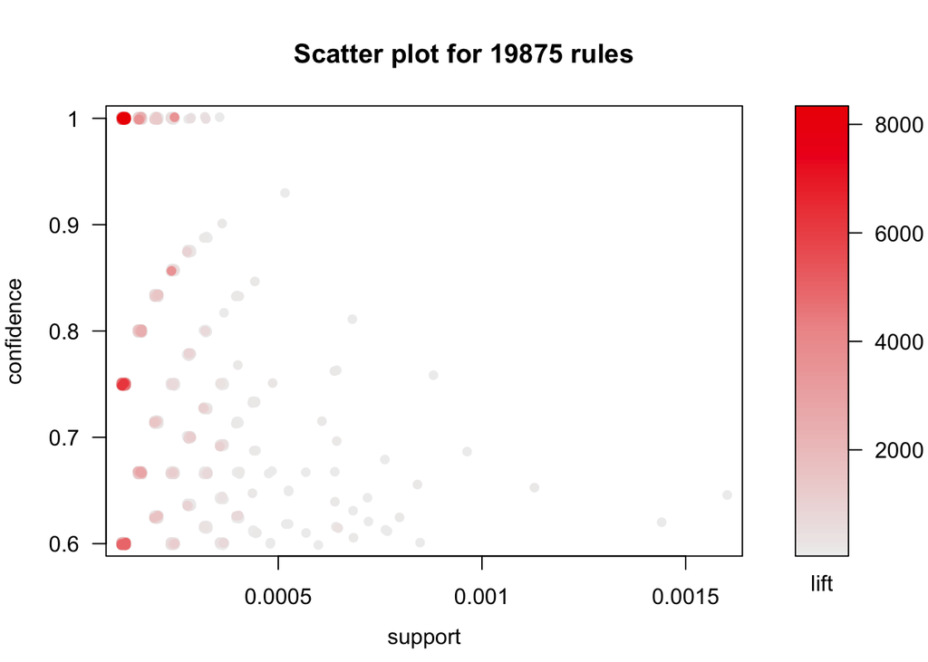

```r
plot(rules1)
```

There’re some rules with a heavy lift indicating a strong association between the items. Further investigate those critical rules:

```r
inspect(sort(rules1,by="lift")[1:10])
```

```
##      lhs                                                   rhs                                                     support confidence     lift count
## [1]  {Wild Blueberry Almond Organic Trail Mix Bar}      => {Organic Cranberry Almond Trail Mix Bar}           0.0001205013          1 8298.667     3
## [2]  {Organic Cranberry Almond Trail Mix Bar}           => {Wild Blueberry Almond Organic Trail Mix Bar}      0.0001205013          1 8298.667     3
## [3]  {Wild Blueberry Almond Organic Trail Mix Bar}      => {Organic Dark Chocolate Pomegranate Trail Mix Bar} 0.0001205013          1 8298.667     3
## [4]  {Organic Dark Chocolate Pomegranate Trail Mix Bar} => {Wild Blueberry Almond Organic Trail Mix Bar}      0.0001205013          1 8298.667     3
## [5]  {Organic Cranberry Almond Trail Mix Bar}           => {Organic Dark Chocolate Pomegranate Trail Mix Bar} 0.0001205013          1 8298.667     3
## [6]  {Organic Dark Chocolate Pomegranate Trail Mix Bar} => {Organic Cranberry Almond Trail Mix Bar}           0.0001205013          1 8298.667     3
## [7]  {Hazelnut Gourmet Coffee Creamer,
##       Natural Chicken Breast in Water}                  => {White & Dark Chunk Chicken}                       0.0001205013          1 8298.667     3
## [8]  {Natural Chicken Breast in Water,
##       Old World Style Meat Flavored Pasta Sauce}        => {White & Dark Chunk Chicken}                       0.0001205013          1 8298.667     3
## [9]  {Natural Chicken Breast in Water,
##       Purified Water}                                   => {White & Dark Chunk Chicken}                       0.0001205013          1 8298.667     3
## [10] {Hazelnut Gourmet Coffee Creamer,
##       Old World Style Meat Flavored Pasta Sauce}        => {White & Dark Chunk Chicken}                       0.0001205013          1 8298.667     3
```

Different flavors of the same type of food have strong association between each other. Coffee creamer and pasta sauce has strong association towards chicken.

```r
inspect(sort(rules1,by="confidence")[1:10])
```

```
##      lhs                                                                                    rhs                                 support confidence        lift count
## [1]  {Premium Solid White Albacore Tuna in Water}                                        => {Hass Avocados}                0.0001205013          1   65.515789     3
## [2]  {Adult Health Small Breed Formula Dry Dog Food}                                     => {Bag of Organic Bananas}       0.0001205013          1    8.674564     3
## [3]  {Brown Sugar Cinnamon Roll Wafflers}                                                => {Banana}                       0.0001205013          1    6.802186     3
## [4]  {Coleslaw Dressing}                                                                 => {3 Color Deli Coleslaw}        0.0001205013          1 1915.076923     3
## [5]  {Frozen Marion Blackberries}                                                        => {Frozen Blueberries}           0.0001205013          1 1185.523810     3
## [6]  {Stonyfield YoToddler Whole Milk Strawberry Beet Berry Yogurt Pouch}                => {Banana}                       0.0001205013          1    6.802186     3
## [7]  {Salisbury Steak with macaroni and cheese Salisbury Steak with macaroni and cheese} => {Meatloaf and Mashed Potatoes} 0.0001205013          1 1778.285714     3
## [8]  {Tropical Trail Mix}                                                                => {Banana}                       0.0001205013          1    6.802186     3
## [9]  {Organic Lemon Agave Vinaigrette}                                                   => {Bag of Organic Bananas}       0.0001205013          1    8.674564     3
## [10] {Organic Coconut Flour}                                                             => {Almond Meal/Flour}            0.0001205013          1  607.219512     3
```

Now we increase the support and decrease condidence to get rules of some more frequent items but with less confidence.

```r
rules2 <- apriori(transactions,parameter=list(support=0.001,conf=0.4,maxlen=3),control=list(verbose=FALSE))
summary(rules2)
```

```
## set of 61 rules
##
## rule length distribution (lhs + rhs):sizes
##  2  3
## 16 45
##
##    Min. 1st Qu.  Median    Mean 3rd Qu.    Max.
##   2.000   2.000   3.000   2.738   3.000   3.000
##
## summary of quality measures:
##     support           confidence          lift             count
##  Min.   :0.001004   Min.   :0.4000   Min.   :  2.737   Min.   :25.00
##  1st Qu.:0.001125   1st Qu.:0.4286   1st Qu.:  3.092   1st Qu.:28.00
##  Median :0.001285   Median :0.4531   Median :  3.735   Median :32.00
##  Mean   :0.001437   Mean   :0.4692   Mean   : 27.043   Mean   :35.79
##  3rd Qu.:0.001607   3rd Qu.:0.5000   3rd Qu.: 50.057   3rd Qu.:40.00
##  Max.   :0.003334   Max.   :0.6512   Max.   :115.795   Max.   :83.00
##
## mining info:
##          data ntransactions support confidence
##  transactions         24896   0.001        0.4
```

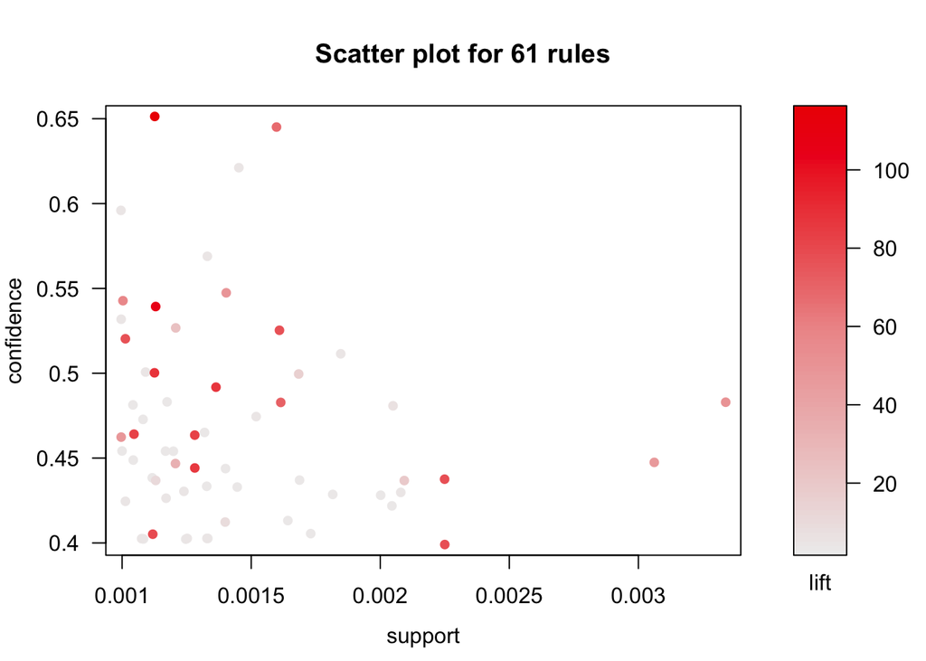

```r
plot(rules2)
```

```r
inspect(sort(rules2,by="lift")[1:10])
```

```
##      lhs                                                rhs                                                 support confidence      lift count
## [1]  {Non Fat Raspberry Yogurt,
##       Vanilla Skyr Nonfat Yogurt}                    => {Icelandic Style Skyr Blueberry Non-fat Yogurt} 0.001124679  0.6511628 115.79535    28
## [2]  {Icelandic Style Skyr Blueberry Non-fat Yogurt,
##       Vanilla Skyr Nonfat Yogurt}                    => {Non Fat Raspberry Yogurt}                      0.001124679  0.5384615 104.73077    28
## [3]  {Icelandic Style Skyr Blueberry Non-fat Yogurt,
##       Non Fat Raspberry Yogurt}                      => {Vanilla Skyr Nonfat Yogurt}                    0.001124679  0.5000000  88.28369    28
## [4]  {Nonfat Icelandic Style Strawberry Yogurt}      => {Vanilla Skyr Nonfat Yogurt}                    0.001365681  0.4927536  87.00421    34
## [5]  {Lemon Sparkling Water}                         => {Grapefruit Sparkling Water}                    0.001285347  0.4444444  85.77433    32
## [6]  {Non Fat Acai & Mixed Berries Yogurt}           => {Icelandic Style Skyr Blueberry Non-fat Yogurt} 0.001044344  0.4642857  82.56327    26
## [7]  {Nonfat Icelandic Style Strawberry Yogurt}      => {Icelandic Style Skyr Blueberry Non-fat Yogurt} 0.001285347  0.4637681  82.47122    32
## [8]  {Nonfat Icelandic Style Strawberry Yogurt}      => {Non Fat Raspberry Yogurt}                      0.001124679  0.4057971  78.92754    28
## [9]  {Icelandic Style Skyr Blueberry Non-fat Yogurt} => {Non Fat Raspberry Yogurt}                      0.002249357  0.4000000  77.80000    56
## [10] {Non Fat Raspberry Yogurt}                      => {Icelandic Style Skyr Blueberry Non-fat Yogurt} 0.002249357  0.4375000  77.80000    56
```

Same type of items have high positive correlation.

```r
inspect(sort(rules2,by="confidence")[1:10])
```

```
##      lhs                                                        rhs                                                         support confidence       lift count
## [1]  {Non Fat Raspberry Yogurt,
##       Vanilla Skyr Nonfat Yogurt}                            => {Icelandic Style Skyr Blueberry Non-fat Yogurt}         0.001124679  0.6511628 115.795349    28
## [2]  {Total 2% Lowfat Greek Strained Yogurt With Blueberry,
##       Total 2% Lowfat Greek Strained Yogurt with Peach}      => {Total 2% with Strawberry Lowfat Greek Strained Yogurt} 0.001606684  0.6451613  66.924731    40
## [3]  {Organic Fuji Apple,
##       Strawberries}                                          => {Banana}                                                0.001446015  0.6206897   4.222046    36
## [4]  {100% Whole Wheat Bread,
##       Strawberries}                                          => {Banana}                                                0.001004177  0.5952381   4.048920    25
## [5]  {Organic Avocado,
##       Organic Fuji Apple}                                    => {Banana}                                                0.001325514  0.5689655   3.870209    33
## [6]  {Zero Calorie Cola}                                     => {Soda}                                                  0.001405848  0.5468750  48.799283    35
## [7]  {Total 2% Greek Strained Yogurt with Cherry 5.3 oz,
##       Total 2% Lowfat Greek Strained Yogurt with Peach}      => {Total 2% with Strawberry Lowfat Greek Strained Yogurt} 0.001004177  0.5434783  56.376812    25
## [8]  {Icelandic Style Skyr Blueberry Non-fat Yogurt,
##       Vanilla Skyr Nonfat Yogurt}                            => {Non Fat Raspberry Yogurt}                              0.001124679  0.5384615 104.730769    28
## [9]  {Blueberries Pint}                                      => {Banana}                                                0.001004177  0.5319149   3.618184    25
## [10] {Total 2% Lowfat Greek Strained Yogurt with Peach,
##       Total 2% with Strawberry Lowfat Greek Strained Yogurt} => {Total 2% Lowfat Greek Strained Yogurt With Blueberry}  0.001606684  0.5263158  76.181151    40
```

Yogurt, fruits, and drinks are often bought together.

Finally, further increase support and decrease confidence.

```r
rules3 <- apriori(transactions,parameter=list(support=0.005,conf=0.1,maxlen=3),control=list(verbose=FALSE))
summary(rules3)
```

```
## set of 97 rules
##
## rule length distribution (lhs + rhs):sizes
##  1  2
##  2 95
##
##    Min. 1st Qu.  Median    Mean 3rd Qu.    Max.
##   1.000   2.000   2.000   1.979   2.000   2.000
##
## summary of quality measures:
##     support           confidence          lift           count
##  Min.   :0.005021   Min.   :0.1015   Min.   :1.000   Min.   : 125.0
##  1st Qu.:0.006025   1st Qu.:0.1470   1st Qu.:1.690   1st Qu.: 150.0
##  Median :0.006949   Median :0.1808   Median :2.099   Median : 173.0
##  Mean   :0.011026   Mean   :0.1906   Mean   :2.278   Mean   : 274.5
##  3rd Qu.:0.009841   3rd Qu.:0.2272   3rd Qu.:2.589   3rd Qu.: 245.0
##  Max.   :0.147012   Max.   :0.3803   Max.   :5.810   Max.   :3660.0
##
## mining info:
##          data ntransactions support confidence
##  transactions         24896   0.005        0.1
```

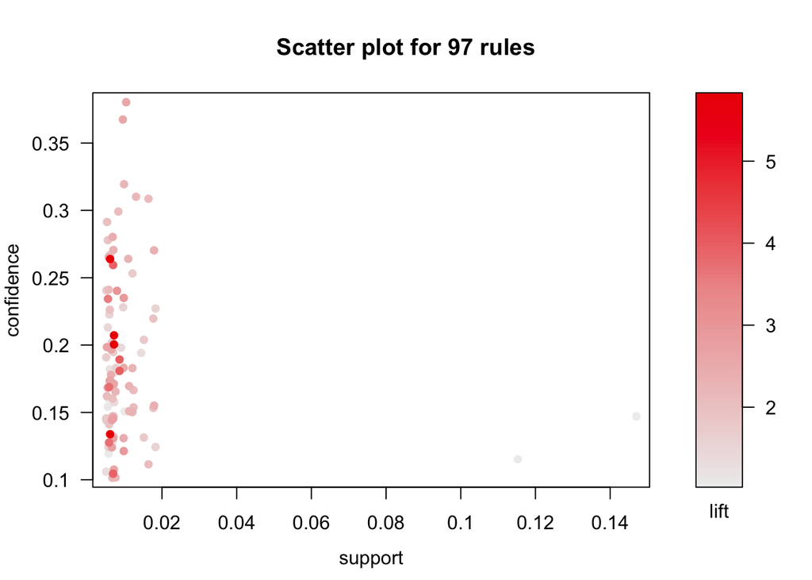

```r
plot(rules3)
```

```r
inspect(sort(rules3,by="lift")[1:10])
```

```
##      lhs                       rhs                    support
## [1]  {Organic Yellow Onion} => {Organic Garlic}       0.007149743
## [2]  {Organic Garlic}       => {Organic Yellow Onion} 0.007149743
## [3]  {Organic Cilantro}     => {Limes}                0.006105398
## [4]  {Limes}                => {Organic Cilantro}     0.006105398
## [5]  {Large Lemon}          => {Limes}                0.008635925
## [6]  {Limes}                => {Large Lemon}          0.008635925
## [7]  {Organic Lemon}        => {Organic Hass Avocado} 0.006908740
## [8]  {Organic Hass Avocado} => {Organic Lemon}        0.006908740
## [9]  {Organic Garlic}       => {Limes}                0.005824229
## [10] {Limes}                => {Organic Garlic}       0.005824229
##      confidence lift     count
## [1]  0.2004505  5.809563 178
## [2]  0.2072177  5.809563 178
## [3]  0.2638889  5.783255 152
## [4]  0.1338028  5.783255 152
## [5]  0.1808242  3.962852 215
## [6]  0.1892606  3.962852 215
## [7]  0.2594268  3.923870 172
## [8]  0.1044957  3.923870 172
## [9]  0.1688009  3.699356 145
## [10] 0.1276408  3.699356 145
```

Fruits and vegetables are highly correlated.

```r
inspect(sort(rules3,by="confidence")[1:10])
```

```
##      lhs                                       rhs                          support confidence     lift count
## [1]  {Organic Fuji Apple}                   => {Banana}                 0.010403278  0.3803231 2.587028   259
## [2]  {Honeycrisp Apple}                     => {Banana}                 0.009519602  0.3674419 2.499408   237
## [3]  {Cucumber Kirby}                       => {Banana}                 0.009840938  0.3194263 2.172797   245
## [4]  {Strawberries}                         => {Banana}                 0.013054306  0.3101145 2.109456   325
## [5]  {Organic Avocado}                      => {Banana}                 0.016388175  0.3086233 2.099313   408
## [6]  {Seedless Red Grapes}                  => {Banana}                 0.008314589  0.2991329 2.034758   207
## [7]  {Blueberries}                          => {Banana}                 0.005302057  0.2913907 1.982094   132
## [8]  {Organic Large Extra Fancy Fuji Apple} => {Bag of Organic Bananas} 0.006788239  0.2802653 2.431180   169
## [9]  {100% Whole Wheat Bread}               => {Banana}                 0.005502892  0.2778905 1.890263   137
## [10] {Apple Honeycrisp Organic}             => {Bag of Organic Bananas} 0.006989075  0.2706065 2.347394   174
```

Lots of fruits. Banana is the most popular fruit among all.